# Prosper Loan Chargeoff Investigation

## by David Sutula

## Investigation Overview

This project looks at data for the Prosper Funding, LLC, a company linking investors to people in need of personal loans. The loans are unsecured. Prosper does not fund the loans themselves. Prosper offers a way to have multiple investors fund individual loans by providing a piece of the funding. Investors are able to view individual loans on their website, see details regarind the total amount the borrower is requesting, view the identified loan ris and borrower APR. According to their website, the typical return on investment is about 5.3%. (This information was obtained on Prosper's website: https://www.prosper.com)

When initially looking at the data, I noticed the dataset provided information regarding loans that are charged off. I am choosing to focus this analysis on loans that are charged-off and what factors may be present in that subset of loans.

As this data was not part of a randomized experiment, findings are not assumed to have causality.

## Dataset Overview

The dataset contains 113,937 rows of data and 81 columns of information, including borrower information, credit rating, amount borrowed, Loan Annual Percentage Rate (APR), information about loan losses, loan status, number of investors and loan funding and was provided to Udacity in support of the Data Analyst Nanodegree Program (Source: https://www.google.com/url?q=https://s3.amazonaws.com/udacity-hosted-downloads/ud651/prosperLoanData.csv&sa=D&ust=1554486256021000).

The dataset included the Prosper Loan Data in a .csv file and a data dictionary (Source: https://www.google.com/url?q=https://docs.google.com/spreadsheet/ccc?key%3D0AllIqIyvWZdadDd5NTlqZ1pBMHlsUjdrOTZHaVBuSlE%26usp%3Dsharing&sa=D&ust=1554486256024000)

## Prosper Loans By Loan Status

In the chart below, we see that Current (meaning payments are being made up to date) is the largest category. Completed loans are the next largest category. The borrowers of these loans finished their payments back to Prosper and their investors. The third largest category is Chargedoff.

```
Total Principal Borrowed - All Loan Status:   $949,894,347.00
```

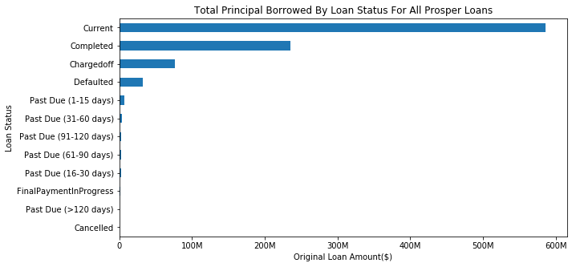

```python
# This code creaates a horizontal bar chart displaying total loan principal amount by loan status.
loan_summary = loan_master.groupby('LoanStatus').LoanOriginalAmount.sum().sort_values().iloc[-12::,].plot(
kind='barh', figsize = (10,5))
loan_summary.xaxis.set_major_formatter(tick.FuncFormatter(reformat_large_tick_values))
plt.title('Total Principal Borrowed By Loan Status For All Prosper Loans')
plt.xlabel('Original Loan Amount($)')
plt.ylabel('Loan Status')
;
print()
print('Total Principal Borrowed - All Loan Status:  ',
      format_currency(sum(loan_master['LoanOriginalAmount']), 'USD', locale='en_US'))
plt.show()
```

## Prosper Loan Types Within Chargedoff Category

The largest group of loans that resulted in chargeoff were in the "Not Available" category (not assigned to a particular category). It was followd by Debt Consolidation, Business Loans, Other and Home Improvement. The loans in the Chargeoff loan status category represent 8% of all amounts loaned by Prosper in the time period.

```
Total Principal Borrowed -- Chargeoff Loan Status Only:   $76,735,809.00
```

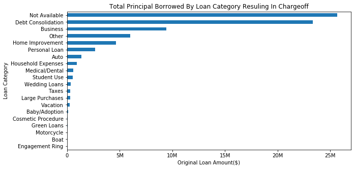

```python
# This code creates a bar chart with total loan amounts by loan type.
ax = loan_chargeoff.groupby('ListingCategory').LoanOriginalAmount.sum().sort_values().iloc[-20::,].plot(
kind='barh', figsize = (10,5))
ax.xaxis.set_major_formatter(tick.FuncFormatter(reformat_large_tick_values))
plt.title('Total Principal Borrowed By Loan Category Resuling In Chargeoff')
plt.xlabel('Original Loan Amount($)')
plt.ylabel('Loan Category')
;
print()
print('Total Principal Borrowed -- Chargeoff Loan Status Only:  ',
      format_currency(sum(loan_chargeoff['LoanOriginalAmount']), 'USD', locale='en_US'))
plt.show()
```

## Distribution Of Loans In Chargedoff Category By Loan Amount

Looking at the distribution of Original Loan Amounts, in the Chargeoff category, borrowed from Prosper, we see the following:

```
The smallest loan was:  $1,000.00
The largest loan was:  $25,000.00
```

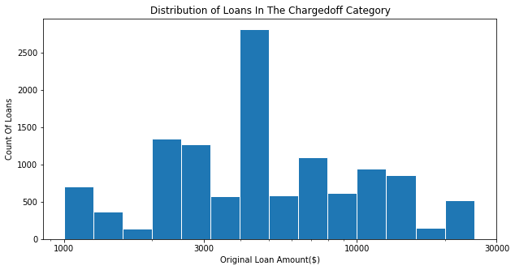

```python
# This code creates a histogram chart showing the distribution of total amounts borrowed resulting in chargeoffs.
# In addition, a log transformation was performed on the x-axis and new scale was applied.
bins = 10** (np.arange(3,np.log10(loan_chargeoff.LoanOriginalAmount.max()) + 0.1, 0.1))
bins = [round(x,1) for x in bins]
plt.figure(figsize=[10,5])
n, bins, patches = plt.hist(data =loan_chargeoff, x  = 'LoanOriginalAmount',
                            bins = bins, edgecolor = "white")
plt.xscale('log')
plt.title('Distribution of Loans In The Chargedoff Category')
plt.xlabel('Original Loan Amount($)')
plt.ylabel('Count Of Loans')


tick_locs = [1000, 3000, 10000, 30000]
plt.xticks(tick_locs, tick_locs);
print('The smallest loan was: ',
      format_currency(min(loan_chargeoff['LoanOriginalAmount']), 'USD', locale='en_US'))
print('The largest loan was: ',
      format_currency(max(loan_chargeoff['LoanOriginalAmount']), 'USD', locale='en_US'))
plt.show()
```

## Principal Borrowed By Type Of Loan

The violin plots by Type of Loan confirm what we suspected abovein the previous slide:

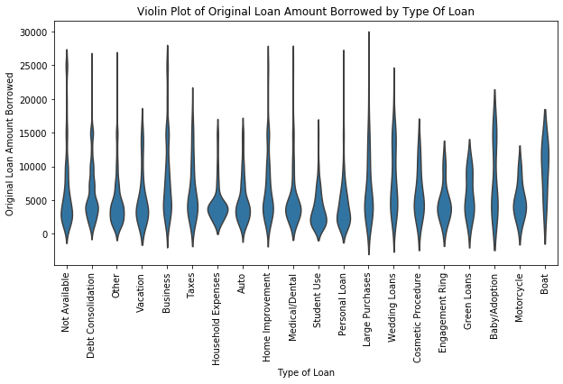

```python
# This code creates a violin plot of Original Loan Amount and Listing Category
plt.figure(figsize = [10,5])
base_color = sb.color_palette()[0]
ax=sb.violinplot(data = loan_chargeoff, x = 'ListingCategory', y = 'LoanOriginalAmount', color = base_color,
              inner = None)
plt.xticks(rotation = 90)
plt.title('Violin Plot of Original Loan Amount Borrowed by Type Of Loan')
plt.ylabel('Original Loan Amount Borrowed')
plt.xlabel('Type of Loan')
plt.show();
```

## Principal Borrowed By Rating Category

Prosper's rating system identifies the level of risk associated with a loan in that rating category on an annual basis: AA = 0 - 1.99%, A = 2.0 - 3.99%, B = 4 - 5.99%, C = 6 - 8.99%, D = 9 - 11.99%, E = 12 - 14.99%, and HR = >= 15.00%.

Rating D has the largest amount of loans, followed by C, E and B (in descending order). A and AA rated loans are the smallest group that received loans. These loans have the lowest risk.

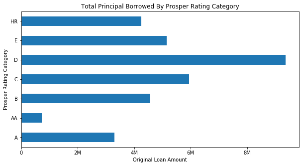

```python
# This code creates a bar chart of total amount borrowed by Borrower's Prosper Risk Rating.
ax = loan_chargeoff.groupby('ProsperRatingAlpha').LoanOriginalAmount.sum().iloc[-20::,].plot(
kind='barh', figsize = (10,5))
ax.xaxis.set_major_formatter(tick.FuncFormatter(reformat_large_tick_values))
plt.title('Total Principal Borrowed By Prosper Rating Category')
plt.xlabel('Original Loan Amount')
plt.ylabel('Prosper Rating Category')
plt.show();
```

## Distribution Of Borrower APR

The following items were observed regarding interest rates for loans falling into the Chargeoff Status:

- The majority of the interest rates fall between 10% and 38%.
- The distribution of Borrower Annual Percentage Rate appears to be multimodal, with additional peaks at 30%, around 35% and around 38%.

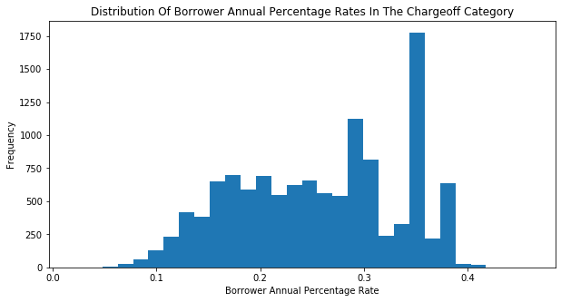

```python
# This code creates a histogram of Borrower Annual Percentage Rates in the chargeoff category.
ax=loan_chargeoff.BorrowerAPR.plot(
kind='hist', figsize = (10,5), bins=30)
plt.title('Distribution Of Borrower Annual Percentage Rates In The Chargeoff Category')
plt.ylabel('Frequency')
plt.xlabel('Borrower Annual Percentage Rate')
plt.show();
```

## Borrower APR By Prosper Rating

Looking at the interquartile ranges in the boxplot above, we can see:

- Risk is the primary factor in determining what Borrower APR is assigned to the loan.
- The AA Prosper Rating has the lowest risk and has a median interest rate near 10%
- As risk increases, so does the median interest rate.
- The highest interest rates were assigned to the HR category.

Each of the ratings in the boxplots has outliers. Further analysis should explore what factors drove assigning Annual Percentage Rates for those outliers.

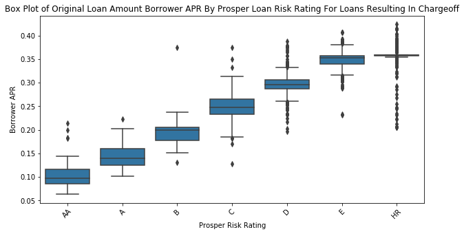

```python
# This code creates a boxplot of Prosper Rating and borrower apr for loans resulting in chargeoff.
plt.figure(figsize = [10, 5])
base_color = sb.color_palette()[0]
sb.boxplot(data = loan_chargeoff, x = 'ProsperRatingAlpha', y = 'BorrowerAPR', color = base_color,
          order = ["AA", "A", "B", "C", "D", "E", "HR"])
plt.xticks(rotation = 45)
plt.title('Box Plot of Original Loan Amount Borrower APR By Prosper Loan Risk Rating For Loans Resulting In Chargeoff')
plt.ylabel('Borrower APR')
plt.xlabel('Prosper Risk Rating')
plt.show();
```

## Emplyment Status By Prosper Loan Risk Rating

Looking at the Employment Status by Prosper Loan Risk Rating for loans resulting in chargeoff, the following was observed:

- The largest group of chargeoff loans is for those who are identified as employed, followed by those identifed as working full-time.
- Within the employed and full-time categories, the D rating appears to be the highest.
- E and HR also appear to be high in almost every loan category for loans that resulted in chargeoff.

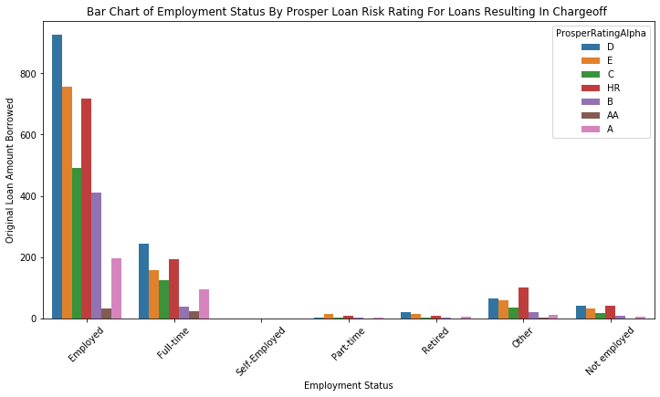

```python
# This code creates a bar chart showing the different employment categories for loans resulting in chargeoff.
# The different bar colors correspond to the Prosper borrower risk ratings.
plt.figure(figsize = [12, 6])
base_color = sb.color_palette()[0]
sb.countplot(data = loan_chargeoff, x = 'EmploymentStatus', hue='ProsperRatingAlpha',
           order = ["Employed", "Full-time", "Self-Employed", "Part-time", "Retired", "Other", "Not employed"])
plt.xticks(rotation = 45)
plt.title('Bar Chart of Employment Status By Prosper Loan Risk Rating For Loans Resulting In Chargeoff ')
plt.ylabel('Original Loan Amount Borrowed')
plt.xlabel('Employment Status')
plt.show();
```

## Relationship Between Numeric Variables In Prosper Loan Data

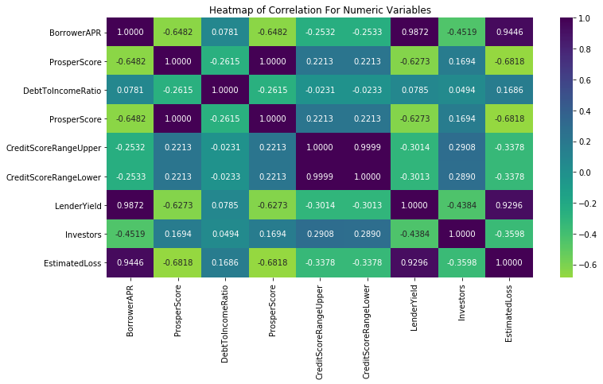

```python
numeric_variables = ['BorrowerAPR', 'ProsperScore', 'DebtToIncomeRatio',
                     'ProsperScore', 'CreditScoreRangeUpper', 'CreditScoreRangeLower', 'LenderYield', 'Investors',
                     'EstimatedLoss']

plt.figure(figsize = [12, 6]);
sb.heatmap(samples_loan[numeric_variables].corr(), annot=True,
          cmap = 'viridis_r', center = 0, fmt = '.4f');
plt.title('Heatmap of Correlation For Numeric Variables')
plt.show();
```

## Effect of Lender Yield and Estimated Loss On The Number Of Investors

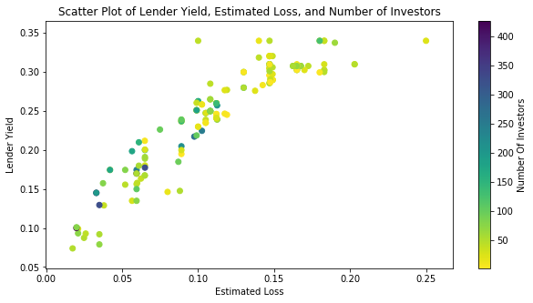

```python
# this code creates a scatter plot of Lender Yield and Estimated loss wil color showing the number of investors
# at each lender yield and estimated loss level.
plt.figure(figsize = [10, 5])
plt.scatter(data=samples_loan, x='EstimatedLoss', y='LenderYield', c = 'Investors',
           cmap = 'viridis_r')
plt.colorbar(label = 'Number Of Investors');
plt.title('Scatter Plot of Lender Yield, Estimated Loss, and Number of Investors')
plt.ylabel('Lender Yield')
plt.xlabel('Estimated Loss')
plt.show();
```